# Week 3: Relationships

Carole Voulgaris

9/10/2020

For this assignment, you’ll be using the following libraries, so make sure they’re installed ahead of time.

```r
library(tidyverse)
library(ggplot2)
```

Let’s start by loading the household-level dataset we created in week 1.

Again, `read_csv()` loads the data into our environment.

I’m going to recode a couple of variables as well.

```r
hh_data <- read_csv("households.csv") %>%
  mutate(struct_type = case_when(
    BLD_label=="2 Apartments"~"Building with fewer\nthan 10 apartments",
    BLD_label=="10-19 Apartments"~"Building with 10\nto 49 apartments",
    BLD_label=="One-family house detached" ~ "Single-family home",
    BLD_label=="3-4 Apartments" ~ "Building with fewer\nthan 10 apartments",
    BLD_label=="Mobile home or trailer" ~ "Mobile home or vehicle",
    BLD_label=="50 or more apartments" ~ "Building with 50+\napartments",
    BLD_label=="20-49 Apartments" ~ "Building with 10\nto 49 apartments",
    BLD_label=="5-9 Apartments"~"Building with fewer\nthan 10 apartments",
    BLD_label=="One-family house attached" ~ "Single-family home",
    BLD_label=="Boat, RV, van, etc." ~ "Mobile home or vehicle"))
```

## Relationship between two continuous variables

```r
correlation <- cor.test(hh_data$age_struct, hh_data$GRNTP)

correlation
```

```
##
##  Pearson's product-moment correlation
##
## data:  hh_data$age_struct and hh_data$GRNTP
## t = -12.257, df = 60510, p-value < 2.2e-16
## alternative hypothesis: true correlation is not equal to 0
## 95 percent confidence interval:
##  -0.05771241 -0.04181663
## sample estimates:
##         cor
## -0.04976767
```

We can visualize the same relationship with a scatter plot. Since a lot of the dots would be plotted right on top of each other, I’ll make it a litte easier to differentiate among individiual points by making them quite small (`size = 0.5`), making them mostly transparent (`alpha = 0.25`), and jittering their positions.

I’ll also add a trendline to the scatterplot using geom_smooth().

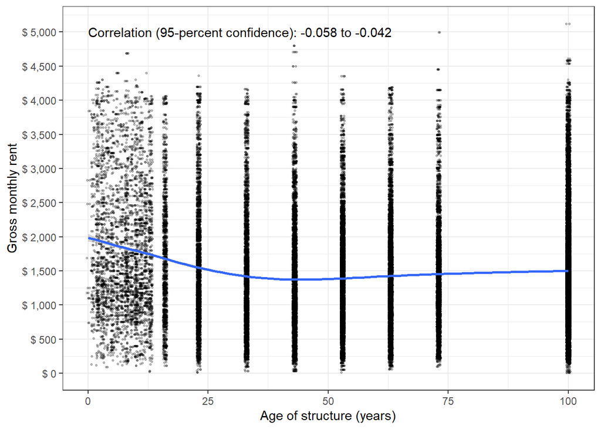

```r
ggplot(hh_data, aes(x = age_struct, y = GRNTP)) +
  geom_point(size = 0.5, alpha = 0.25, position = "jitter") +
  geom_smooth() +
  theme_bw() +
  scale_x_continuous(name = "Age of structure (years)") +
  scale_y_continuous(name = "Gross monthly rent",
                     breaks = seq(0, 6000, by = 500),
                     labels = paste("$",
                                    prettyNum(seq(0, 6000, by = 500),
                                              big.mark = ","))) +
  annotate(geom = "text", x = 0, y = 5000,
           label = paste("Correlation (95-percent confidence):",
                         prettyNum(correlation$conf.int[1], digits = 2),
                         "to",
                         prettyNum(correlation$conf.int[2], digits = 2)),
           hjust = 0)
```

The correlation is pretty weak, but it is statistically signicant. Looking at the trendline, the low magnitude of the correlation might be because the relationship levels off (and may even become positive) for structures that are older than about 40 years.

## Relationship between a continuous variable and a binary variable

In thinking about the relationship between a continuous variable and a binary variable, the question we should ask ourselves is “Is the value of the continuous variable different for one value of the binary variable than for the other?” A two-sample t.test is the perfect tool to answer this question.

For example, do households with limited English proficiency pay higher or lower rents than those with full English proficiency?

```r
difference = t.test(GRNTP ~ LNGI_label == "At least one person in the household 14 and over speaks English only or speaks English 'very well'",
                    data = hh_data)

difference
```

```
##
##  Welch Two Sample t-test
##
## data:  GRNTP by LNGI_label == "At least one person in the household 14 and over speaks English only or speaks English 'very well'"
## t = -15.852, df = 9911, p-value < 2.2e-16
## alternative hypothesis: true difference in means is not equal to 0
## 95 percent confidence interval:
##  -153.9560 -120.0705
## sample estimates:
## mean in group FALSE  mean in group TRUE
##            1369.657            1506.670
```

Households with limited English proficiency generally pay lower rents than those with full English proficiency. We can visualize this result with a violin plot.

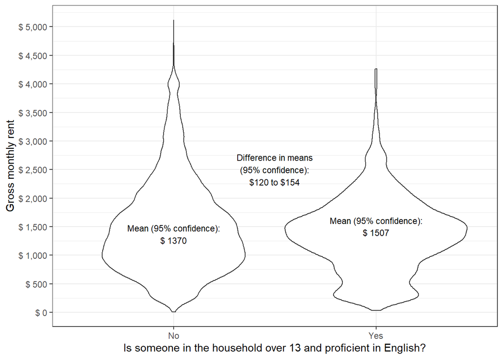

```r
ggplot(hh_data, aes(x = LNGI_label, y = GRNTP)) +
  geom_violin() +
  theme_bw() +
  scale_x_discrete(name = "Is someone in the household over 13 and proficient in English?",
                   labels = c("No", "Yes")) +
   scale_y_continuous(name = "Gross monthly rent",
                     breaks = seq(0, 6000, by = 500),
                     labels = paste("$",
                                    prettyNum(seq(0, 6000, by = 500),
                                              big.mark = ","))) +
  annotate(geom = "text", x = 1.5, y = 2500, size = 3,
           label = paste("Difference in means\n(95% confidence):\n$",
                         prettyNum(abs(difference$conf.int[2]),
                                   digits = 0), " to $",
                         prettyNum(abs(difference$conf.int[1]),
                                   digits = 0),
                         sep = "")) +
  annotate(geom = "text", x = 1, y = difference$estimate[1], size = 3,
           label = paste("Mean (95% confidence):\n$",
                         prettyNum(difference$estimate[1], digits = 0))) +
  annotate(geom = "text", x = 2, y = difference$estimate[2], size = 3,
           label = paste("Mean (95% confidence):\n$",
                         prettyNum(difference$estimate[2], digits = 0)))
```

## Relationship between a continuous variable and a categorical variable (three or more levels)

```r
anova <- aov(GRNTP ~ struct_type, data = hh_data)

summary(anova)
```

```
##                Df    Sum Sq   Mean Sq F value Pr(>F)
## struct_type     4 4.847e+08 121178378     193 <2e-16 ***
## Residuals   60507 3.798e+10    627759
## ---
## Signif. codes:  0 '***' 0.001 '**' 0.01 '*' 0.05 '.' 0.1 ' ' 1
```

The p-value is much lower than 0.05, so this tells us that, at a 95-percent confidence interval, there is a significant association between the type of structure and the monthly rent. We can take this a step further by doing a Tukey’s Honestly Significant Difference test to see the magnitude of the differences among the difference categories.

```r
differences <- TukeyHSD(anova)

as_tibble(cbind(pair = row.names(differences$struct_type),
                differences$struct_type))
```

```
## # A tibble: 10 x 5
##    pair                              diff       lwr        upr       `p adj`
##    <chr>                             <chr>      <chr>      <chr>     <chr>
##  1 "Building with 50+\napartments-B~ 102.19279~ 75.121038~ 129.2645~ 5.19584375~
##  2 "Building with fewer\nthan 10 ap~ 48.830183~ 25.236617~ 72.42374~ 1.64288077~
##  3 "Mobile home or vehicle-Building~ -556.1247~ -626.0566~ -486.192~ 0
##  4 "Single-family home-Building wit~ 111.99622~ 83.426969~ 140.5654~ 4.76285677~
##  5 "Building with fewer\nthan 10 ap~ -53.36261~ -77.23107~ -29.4941~ 1.06984812~
##  6 "Mobile home or vehicle-Building~ -658.3175~ -728.3426~ -588.292~ 0
##  7 "Single-family home-Building wit~ 9.8034243~ -18.99326~ 38.60011~ 0.88589323~
##  8 "Mobile home or vehicle-Building~ -604.9549~ -673.7102~ -536.199~ 0
##  9 "Single-family home-Building wit~ 63.166039~ 37.611675~ 88.72040~ 1.55585322~
## 10 "Single-family home-Mobile home ~ 668.12097~ 597.50344~ 738.7385~ 0
```

Again, you could visulize those differences with a violin plot. Just for the sake of variety though, let’s do a box plot.

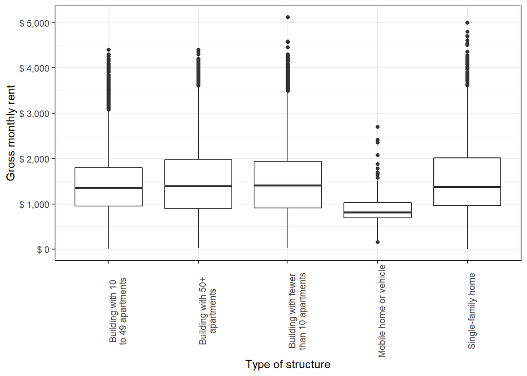

```r
ggplot(hh_data, aes(x = struct_type, y = GRNTP)) +
  geom_boxplot() +
  theme_bw() +
  theme(axis.text.x = element_text(angle = 90)) +
  scale_x_discrete(name = "Type of structure") +
  scale_y_continuous(name = "Gross monthly rent",
                     breaks = seq(0, 6000, by = 1000),
                     labels = paste("$",
                                    prettyNum(seq(0, 6000, by = 1000),
                                              big.mark = ",")))
```

## Relatship between two categorical variables

The Chi-square test of association is for determining whether there is a statistically significant association between two categorical variables. It’s based on calculating the number of observations in each possible combination of categories and comparing that distribution to what you would expect if there was no relationship.

Is there a relationship between the type of structure a household lives in and their English proficiency?

```r
chi_sq <- chisq.test(hh_data$struct_type, hh_data$LNGI_label ==
                       "At least one person in the household 14 and over speaks English only or speaks English 'very well'")

chi_sq
```

```
##
##  Pearson's Chi-squared test
##
## data:  hh_data$struct_type and hh_data$LNGI_label == "At least one person in the household 14 and over speaks English only or speaks English 'very well'"
## X-squared = 690.73, df = 4, p-value < 2.2e-16
```

The p-value is much less than 0.05, so the relationship is significant at a 95-percent confidence level.

Here are the values we observe for each combination of variables (`TRUE` and `FALSE` refer to whether there is a household member over the age of 14 who speaks English either exclusively or “very well”).

```r
chi_sq$observed
```

```
##
## hh_data$struct_type                       FALSE  TRUE
##   Building with 10\nto 49 apartments       1816 11162
##   Building with 50+\napartments            1861 10663
##   Building with fewer\nthan 10 apartments  2707 21035
##   Mobile home or vehicle                     31  1000
##   Single-family home                        533  9704
```

Here are the values we would expect if the two variables were not related:

```r
chi_sq$expected
```

```
##
## hh_data$struct_type                           FALSE       TRUE
##   Building with 10\nto 49 apartments      1490.1366 11487.8634
##   Building with 50+\napartments           1438.0082 11085.9918
##   Building with fewer\nthan 10 apartments 2726.0612 21015.9388
##   Mobile home or vehicle                   118.3796   912.6204
##   Single-family home                      1175.4144  9061.5856
```